# Mixed_Linear_Regression

2025-07-23

```r
# importing libraries
library(tidyverse)
library(randomForest)
library(dplyr)
library(nlme)
```

```r
library(corrplot)
library(reshape2)
```

There are still 25 variables - this model can be simplified. To understand the impact of each variable a correlation matrix can show us which variables are highly correlated.

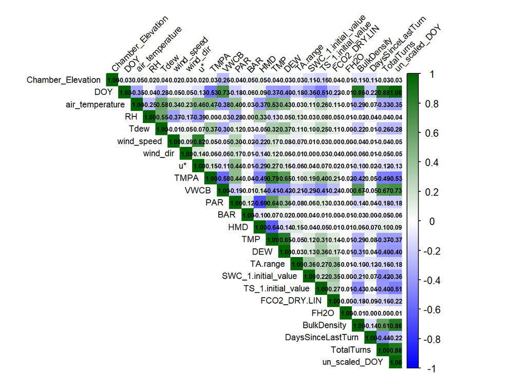

```r
# before choosing variables for the LME lets look at correlation matrix
# this is a mess, and there are too many variables to properly interpret the results

# looking at only numerical variables
numeric_vars <- df_categorized[sapply(df_categorized, is.numeric)]

# creating corr matrix
cor_matrix <- cor(numeric_vars, use = "pairwise.complete.obs", method = "pearson")
#plotting matrix
corrplot(
  cor_matrix,
  method = "color",         # Color-coded cells
  type = "upper",           # Only upper triangle
  col = colorRampPalette(c("blue", "white", "darkgreen"))(200),  # Custom colors
  tl.cex = 0.7,             # Smaller font size for variable names
  tl.col = "black",         # Text label color
  tl.srt = 45,              # Rotate variable labels
  addCoef.col = "black",    # Add correlation coefficients
  number.cex = 0.5,         # Size of coefficient text
  mar = c(0, 0, 1, 0)       # Reduce margin space
)
```

```r
# extracting highest cor
threshold <- 0.7  #.7 is a personal choice

# Set the diagonal to 0 to ignore self-correlation
cor_matrix_no_diag <- cor_matrix
diag(cor_matrix_no_diag) <- 0

# Get variables that have at least one |cor| > threshold
keep_vars <- names(which(apply(abs(cor_matrix_no_diag), 1, function(x) any(x > threshold))))

cor_subset <- cor_matrix[keep_vars, keep_vars]
cor_long <- melt(cor_subset)

# pairwise list of highest corr in data set
high_corr_pairs <- subset(cor_long, abs(value) > threshold & Var1 != Var2)
print(high_corr_pairs)
```

```
##             Var1          Var2     value
## 5           VWCB           DOY 0.7255849
## 8    BulkDensity           DOY 0.8559357
## 9     TotalTurns           DOY 0.8771654
## 10 un_scaled_DOY           DOY 1.0000000
## 13            u*    wind_speed 0.8161463
## 22    wind_speed            u* 0.8161463
## 36           TMP          TMPA 0.7902757
## 41           DOY          VWCB 0.7255849
## 50 un_scaled_DOY          VWCB 0.7255849
## 54          TMPA           TMP 0.7902757
## 57           DEW           TMP 0.8461523
## 66           TMP           DEW 0.8461523
## 71           DOY   BulkDensity 0.8559357
## 80 un_scaled_DOY   BulkDensity 0.8559357
## 81           DOY    TotalTurns 0.8771654
## 90 un_scaled_DOY    TotalTurns 0.8771654
## 91           DOY un_scaled_DOY 1.0000000
## 95          VWCB un_scaled_DOY 0.7255849
## 98   BulkDensity un_scaled_DOY 0.8559357
## 99    TotalTurns un_scaled_DOY 0.8771654
```

```r
# a basic linear model gives us an idea of the relationship - we are looking here are scaled data - furthermore it is important to not despite the data being scaled it does not mean that one variable is more important than the other as the ranges are not the same.

full_lm <- lm(FCO2_DRY.LIN ~ ., data = df_scaled)
summary(full_lm)
```

```
##
## Call:
## lm(formula = FCO2_DRY.LIN ~ ., data = df_scaled)
##
## Residuals:
##     Min      1Q  Median      3Q     Max
## -1.1155 -0.2029 -0.0154  0.1635  4.3399
##
## Coefficients: (2 not defined because of singularities)
##                      Estimate Std. Error t value Pr(>|t|)
## (Intercept)         -1.229918   1.317923  -0.933 0.350910
## PileE               -1.430634   0.207821  -6.884 9.81e-12 ***
## Chamber_CorrectedC2  0.199413   0.102985   1.936 0.053084 .
## Chamber_CorrectedC3 -0.334356   0.060542  -5.523 4.17e-08 ***
## Chamber_CorrectedC4 -0.077030   0.118723  -0.649 0.516592
## Chamber_CorrectedC6        NA         NA      NA       NA
## Chamber_Elevation    0.128374   0.024177   5.310 1.33e-07 ***
## DOY                  0.009138   0.005527   1.653 0.098528 .
## air_temperature      0.016959   0.055139   0.308 0.758468
## RH                  -0.070881   0.049714  -1.426 0.154217
## Tdew                 0.041239   0.049929   0.826 0.409010
## wind_speed           0.053048   0.027567   1.924 0.054578 .
## wind_dir             0.019936   0.013576   1.468 0.142260
## `u*`                -0.060483   0.031346  -1.930 0.053923 .
## TMPA                 0.385604   0.099916   3.859 0.000120 ***
## VWCB                 0.067967   0.027179   2.501 0.012540 *
## PAR                  0.008216   0.035263   0.233 0.815820
## BAR                 -0.045062   0.039156  -1.151 0.250051
## HMD                 -0.204266   0.189089  -1.080 0.280265
## TMP                 -0.454602   0.397979  -1.142 0.253591
## DEW                  0.285376   0.303402   0.941 0.347125
## TA.range             0.197157   0.041886   4.707 2.84e-06 ***
## SWC_1.initial_value  0.008167   0.044941   0.182 0.855825
## TS_1.initial_value   0.075394   0.034596   2.179 0.029526 *
## FH2O                -0.012787   0.018374  -0.696 0.486624
## BulkDensity          0.140485   0.039977   3.514 0.000459 ***
## DaysSinceLastTurn   -0.159175   0.027401  -5.809 8.23e-09 ***
## TotalTurns          -0.773780   0.141047  -5.486 5.11e-08 ***
## un_scaled_DOY              NA         NA      NA       NA
## ---
## Signif. codes:  0 '***' 0.001 '**' 0.01 '*' 0.05 '.' 0.1 ' ' 1
##
## Residual standard error: 0.4389 on 1090 degrees of freedom
##   (8162 observations deleted due to missingness)
## Multiple R-squared:  0.5279, Adjusted R-squared:  0.5166
## F-statistic: 46.88 on 26 and 1090 DF,  p-value: < 2.2e-16
```

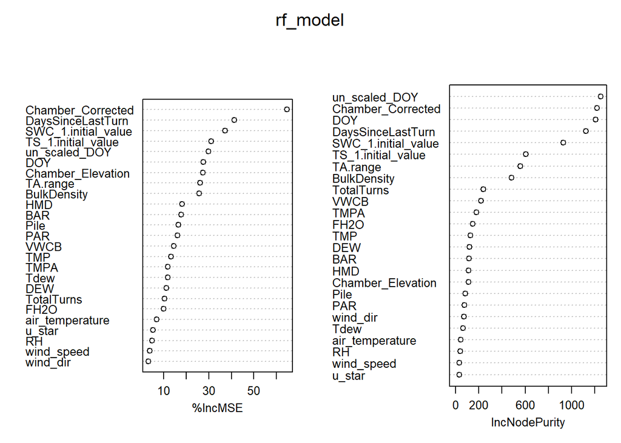

```r
# Key takeaways - Days since turning is important, more important than total turns,
# bulk density is important, chamber elevation is important. Stevens probe measurements and watchdog data will be part of the model.
# odd that wind direction matters, is that because of the wind or is that correlated with something?

# using random forest as well:
# had to change u* name to avoid issues

# TA.range - which is chamber tempurate was an important varaible. Not sure if this is correlation or causation - not sure about this varaible. While it improves the model - im not sure what it represents.


df_categorized <- df_categorized %>%
  rename(u_star = `u*`)

rf_model <- randomForest(FCO2_DRY.LIN ~ ., data = df_categorized, importance = TRUE, na.action = na.omit)

# Example 1: Increase margins and text size
par(mar = c(5, 8, 4, 2))  # Increase left margin for long labels
varImpPlot(rf_model, cex = 0.8)  # cex = character size
```

In our Linear Model with 26 variables we can explain around 50% of the variability in magnitude of flux. Based on the basic linear model variables which are significant (not necessarily important just significant this is not looking at effect size). Pile, Chamber 3 (not sure about what is going on here), Chamber 2 to a lesser extent, Chamber elevation, windspeed, Temp Range (TA range which is temp range measured in chamber), pile temperature, bulk density, days since last turn, total turns.

Looking at the random forest model there are similiar trends.Looking at variables with the highest %IncMSE - Chamber - Days since last turn - SWC intial value - TS initial value - Bulk Density - TA range - Chamber elevation - meterological var - total turns is further down - interesting - though it still is an importnat variable

Both linear and RF models help us select important variables for Mixed effects Model.

```r
# To help with model building removing outliers (being generous with a 2 times IQR could use a higher value as there are likely spikes from turning)

# defining the quantiles
Q1 <- quantile(df_categorized$FCO2_DRY.LIN, 0.25)
Q3 <- quantile(df_categorized$FCO2_DRY.LIN, 0.75)
# the interquartile range
iqr_val <- IQR(df_categorized$FCO2_DRY.LIN, na.rm = TRUE)

# creating the boundaries
lower_bound <- Q1 - 2* iqr_val
upper_bound <- Q3 + 2* iqr_val

# Filtering out outliers -
Scaled_Cleaned_Co2_data <- df_categorized[df_categorized$FCO2_DRY.LIN >= lower_bound & df_categorized$FCO2_DRY.LIN <= upper_bound, ]

# creating the base model.

# Variable choice:

# Pile
# Initial Soil Water Content from Steven's Probe
# Initial Temperature value from the Steven's Probe
# TMP - outside temp
# BAR - pressure
# Bulk Density
# Chamber Elevation
# Total turns
# HMD - Humidity
# TA.range

# Base model

gls.co2 = gls(FCO2_DRY.LIN ~ Pile, na.action = na.omit, data = Scaled_Cleaned_Co2_data)

# Base linear mixed effects model, Random effect of chamber

lme_base_model <- lme(
  FCO2_DRY.LIN ~ Pile + SWC_1.initial_value + TS_1.initial_value +
    TMP + BAR + BulkDensity + Chamber_Elevation +
    DaysSinceLastTurn + TotalTurns + HMD + TA.range,
  random = ~ 1 | Chamber_Corrected,
  data = Scaled_Cleaned_Co2_data,
  na.action = na.omit
)

summary(lme_base_model)
```

```
## Linear mixed-effects model fit by REML
##   Data: Scaled_Cleaned_Co2_data
##        AIC      BIC   logLik
##   10908.88 11008.13 -5440.44
##
## Random effects:
##  Formula: ~1 | Chamber_Corrected
##         (Intercept)  Residual
## StdDev:   0.2550088 0.4439518
##
## Fixed effects:  FCO2_DRY.LIN ~ Pile + SWC_1.initial_value + TS_1.initial_value +      TMP + BAR + BulkDensity + Chamber_Elevation + DaysSinceLastTurn +      TotalTurns + HMD + TA.range
##                           Value  Std.Error   DF   t-value p-value
## (Intercept)         -0.13263637 0.14746868 8856 -0.899421  0.3685
## PileE               -0.01636875 0.20876679    4 -0.078407  0.9413
## SWC_1.initial_value  0.09674275 0.00778367 8856 12.428936  0.0000
## TS_1.initial_value   0.20690055 0.00752481 8856 27.495794  0.0000
## TMP                  0.04876489 0.00715835 8856  6.812309  0.0000
## BAR                 -0.00803582 0.00465582 8856 -1.725972  0.0844
## BulkDensity         -0.04217384 0.00811760 8856 -5.195358  0.0000
## Chamber_Elevation    0.06878902 0.00921789 8856  7.462554  0.0000
## DaysSinceLastTurn   -0.04432112 0.00581447 8856 -7.622555  0.0000
## TotalTurns           0.01381389 0.00942417 8856  1.465794  0.1427
## HMD                  0.01720184 0.00648658 8856  2.651911  0.0080
## TA.range             0.08467662 0.00632583 8856 13.385849  0.0000
##  Correlation:
##                     (Intr) PileE  SWC_1. TS_1._ TMP    BAR    BlkDns Chmb_E
## PileE               -0.707
## SWC_1.initial_value  0.017 -0.028
## TS_1.initial_value  -0.009  0.016 -0.172
## TMP                 -0.001  0.001  0.108 -0.284
## BAR                  0.001 -0.001  0.012  0.014  0.007
## BulkDensity          0.028 -0.043  0.107  0.125 -0.034  0.004
## Chamber_Elevation    0.008 -0.011  0.127  0.169  0.023  0.057  0.230
## DaysSinceLastTurn    0.005 -0.008  0.205  0.018  0.157  0.049 -0.048  0.192
## TotalTurns          -0.024  0.037  0.154  0.153  0.267  0.039 -0.643  0.019
## HMD                 -0.001  0.001  0.099 -0.140  0.654  0.071 -0.019 -0.013
## TA.range             0.009 -0.010 -0.159 -0.288  0.118  0.003  0.027  0.035
##                     DysSLT TtlTrn HMD
## PileE
## SWC_1.initial_value
## TS_1.initial_value
## TMP
## BAR
## BulkDensity
## Chamber_Elevation
## DaysSinceLastTurn
## TotalTurns           0.390
## HMD                  0.105  0.145
## TA.range             0.162 -0.009 -0.062
##
## Standardized Within-Group Residuals:
##         Min          Q1         Med          Q3         Max
## -3.14483411 -0.67713831 -0.07315114  0.50652321  4.47632772
##
## Number of Observations: 8872
## Number of Groups: 6
```

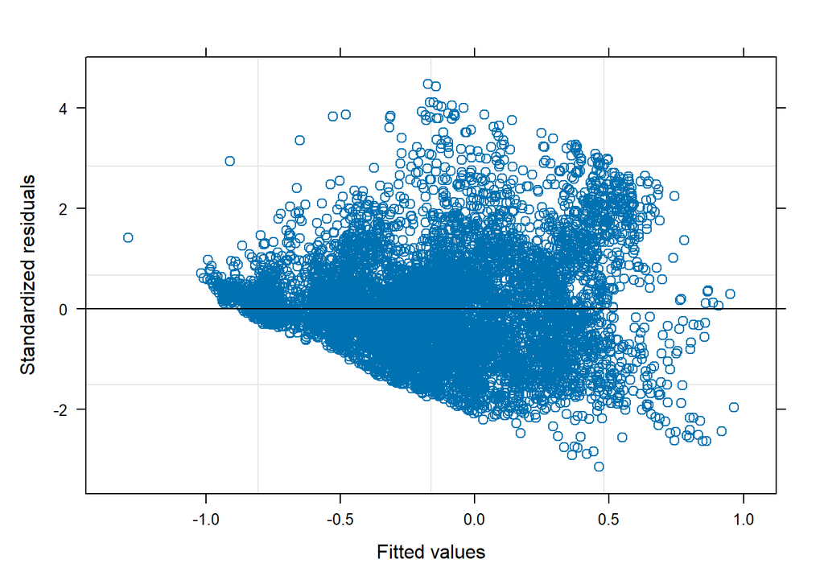

```r
plot(lme_base_model)
```

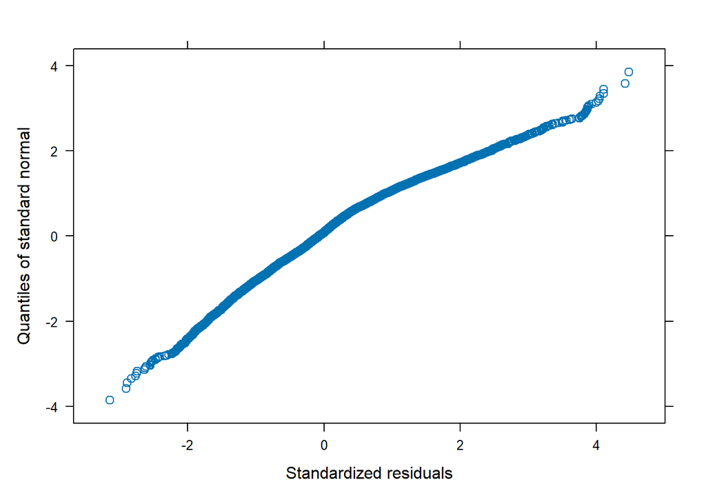

```r
qqnorm(lme_base_model)
```